# Model fit showcase

Gilles Lijnzaad

2026-10-08

> In this document, I explain the code for my standard Stan model of the climate-RL task (without confirmation bias) and demonstrate parameter recovery.

# Helper files

In this R markdown I use code from the following files: [sim_utils.R](https://gilleslijnzaad.github.io/climate-RL-modeling/all_utils.html#sim_utilsR), [plot_utils.R](https://gilleslijnzaad.github.io/climate-RL-modeling/all_utils.html#plot_utilsR), [fit_utils.R](https://gilleslijnzaad.github.io/climate-RL-modeling/all_utils.html#fit_utilsR), and [utils.R](https://gilleslijnzaad.github.io/climate-RL-modeling/all_utils.html#utilsR).

# 1 Creating the data

## 1.1 Running the simulation

```r
rm(list = ls())
setwd("~/research/climate-RL-mod/2_modeling_showcase")
main_dir <- "~/research/climate-RL-mod/"
util_dir <- paste0(main_dir, "9_utilities/")
mod_dir <- paste0(main_dir, "0_models/")
model_path <- paste0(mod_dir, "1_std.stan")

sim <- new.env()
source(paste0(mod_dir, "1_std.R"), local = sim) # access functions using sim$fun()

params <- list(
  n_part = 50,
  n_trials = 30,
  LR_group = 0.4,
  inv_temp_group = 0.5,
  initQ_dev_group = 2,
  mu_R_group = 5.5,
  sigma_R_group = 2
)

sim_dat <- sim$run(params)

cat(paste0("PARAMETER SETTINGS:"), capture.output(dplyr::glimpse(params)), sep = "\n")
```

```
PARAMETER SETTINGS:
List of 7
 $ n_part         : num 50
 $ n_trials       : num 30
 $ LR_group       : num 0.4
 $ inv_temp_group : num 0.5
 $ initQ_dev_group: num 2
 $ mu_R_group     : num 5.5
 $ sigma_R_group  : num 2
```

```r
cat(paste0("SIMULATED DATA:"), capture.output(dplyr::glimpse(sim_dat)), sep = "\n")
```

```
SIMULATED DATA:
Rows: 1,500
Columns: 10
$ participant <int> 1, 1, 1, 1, 1, 1, 1, 1, 1, 1, 1, 1, 1, 1, 1, 1, 1, 1, 1, 1…
$ trial       <int> 1, 2, 3, 4, 5, 6, 7, 8, 9, 10, 11, 12, 13, 14, 15, 16, 17,…
$ Q_pref      <dbl> 6.590587, 6.428347, 6.428347, 5.761258, 5.002715, 4.727260…
$ Q_nonpref   <dbl> 3.137140, 3.137140, 4.473012, 4.473012, 4.473012, 4.473012…
$ choice_c    <dbl> 1, 2, 1, 1, 1, 1, 1, 2, 2, 1, 1, 2, 2, 2, 1, 2, 2, 1, 1, 1…
$ R           <dbl> 6, 8, 4, 3, 4, 7, 4, 4, 6, 7, 3, 6, 4, 6, 4, 5, 6, 5, 4, 2…
$ mu_R        <dbl> 4.863863, 4.863863, 4.863863, 4.863863, 4.863863, 4.863863…
$ LR          <dbl> 0.2747092, 0.2747092, 0.2747092, 0.2747092, 0.2747092, 0.2…
$ inv_temp    <dbl> 0.3163921, 0.3163921, 0.3163921, 0.3163921, 0.3163921, 0.3…
$ initQ_dev   <dbl> 1.726724, 1.726724, 1.726724, 1.726724, 1.726724, 1.726724…
```

## 1.2 Inspecting the data

Just so I know what to expect of our model, I include plots of the simulated data: Q and choices over time.

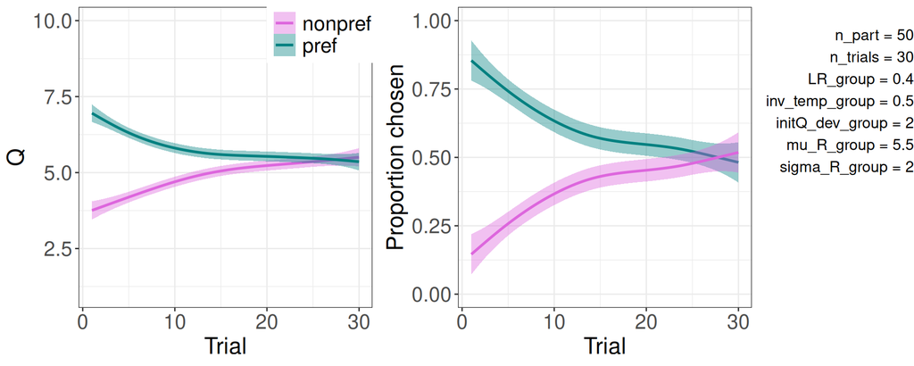

```r
plot <- new.env()
source(paste0(util_dir, "plot_utils.R"), local = plot) # access functions using plot$fun()

plot$sim_plots(sim_dat, params)
```

# 2 Explaining the model

I show the Stan model code bit by bit to explain what is happening. The full code can be found in `1_std.stan`.

## 2.1 `data` block

The data we supply to the model consist of:

1. the number of participants: `n_part`;
2. the number of trials per participant: `n_trials`;
3. an array of choices that a participant made: `choice_c[n_part, n_trials]`, coded as (1) consistent with the very first choice (hence `choice_c`) or (2) not consistent with the first choice;
4. an array of ratings that a participant gave: `R[n_part, n_trials]`. These are analogous to the array `outcomes[n_trials]` in the `2arm_bandit_example` (see [Stan code](https://github.com/CCS-Lab/hBayesDM/blob/develop/commons/stan_files/bandit2arm_delta.stan) for this example);
5. the mean rating of a participant, as calculated from the data: `mu_R[n_part]`.

```r
mod_code <- readLines(model_path)
start <- grep("data \\{", mod_code)[1]
end <- grep("transformed data \\{", mod_code) - 2
cat(mod_code[start:end], sep = "\n")
```

```
data {
  int<lower=1> n_part;
  int<lower=1> n_trials;
  array[n_part, n_trials] int<lower=1, upper=2> choice_c;
  array[n_part, n_trials] int<lower=1, upper=10> R;
  vector<lower=1, upper=10>[n_part] mu_R;
}
```

## 2.2 `transformed data` block

Currently unused.

```r
start <- grep("transformed data \\{", mod_code)
end <- grep("parameters \\{", mod_code)[1] - 2
cat(mod_code[start:end], sep = "\n")
```

## 2.3 `parameters` block

In the current model, we have three free parameters:

1. learning rate `LR`;
2. inverse temperature `inv_temp`;
3. deviation from the mean for initial Q: `initQ_dev`. This is related to the actual initial Qs as:

> `initQ_pref = mu_R + initQ_dev` `initQ_nonpref = mu_R - initQ_dev`

where `mu_R` is calculated from the data.

```r
start <- grep("parameters \\{", mod_code)[1]
end <- grep("transformed parameters \\{", mod_code) - 2
cat(mod_code[start:end], sep = "\n")
```

```
parameters {
  // group-level parameters
  vector[3] means_probit;
  vector<lower=0>[3] sigmas;

  // participant-level parameters
  vector[n_part] LR_probit;
  vector[n_part] inv_temp_probit;
  vector[n_part] initQ_dev_probit;
}
```

## 2.4 `transformed parameters` block

```r
start <- grep("transformed parameters \\{", mod_code)
end <- grep("model \\{", mod_code) - 2
cat(mod_code[start:end], sep = "\n")
```

[output not shown]

## 2.5 `model` block

### 2.5.1 The priors

```r
start <- grep("model \\{", mod_code)
end <- grep("participant loop", mod_code)[1] - 2
cat(mod_code[start:end], sep = "\n")
```

```
model {
  // priors
  means_probit ~ normal(0, 1);
  sigmas ~ normal(0, 0.2);

  LR_probit ~ normal(0, 1);
  inv_temp_probit ~ normal(0, 1);
  initQ_dev_probit ~ normal(0, 1);
```

### 2.5.2 Participant loop

```r
start <- grep("participant loop", mod_code) + 1
end <- grep("trial loop", mod_code) - 2
cat(mod_code[start:end], sep = "\n")
```

```
  for (j in 1:n_part) {

    // initialization
    array[n_trials, 2] real Q;
    Q[1, 1] = mu_R[j] + initQ_dev[j];
    Q[1, 2] = mu_R[j] - initQ_dev[j];
    vector[2] Q_t;
    real pred_err;
```

### 2.5.3 Trial loop

```r
start <- grep("trial loop", mod_code) + 1
end <- grep("generated quantities", mod_code) - 2
cat(mod_code[start:end], sep = "\n")
```

```
    for (t in 1:n_trials) {
      Q_t = to_vector(Q[t]);

      // sample choice (1 is pref, 2 is nonpref) via softmax
      // but not for trial 1
      if (t > 1) {
        choice_c[j, t] ~ categorical_logit(inv_temp[j] * Q_t);
      }

      // prediction error
      pred_err = R[j, t] - Q[t, choice_c[j, t]];

      // update value (learn)
      if (t < n_trials) {    // no updating in the very last trial
        if (choice_c[j, t] == 1) {
          Q[t+1, 1] = Q[t, 1] + LR[j] * pred_err;
          Q[t+1, 2] = Q[t, 2];
        } else {
          Q[t+1, 1] = Q[t, 1];
          Q[t+1, 2] = Q[t, 2] + LR[j] * pred_err;
        }
      }
    }
  }
}
```

## 2.6 `generated quantities` block

```r
start <- grep("generated quantities", mod_code)
end <- length(mod_code)
cat(mod_code[start:end], sep = "\n")
```

```
generated quantities {
  vector[3] means;
  means[1] = Phi_approx(means_probit[1]); // LR_group
  means[2] = Phi_approx(means_probit[2]) * 5; // inv_temp_group
  means[3] = Phi_approx(means_probit[3]) * 10; // initQ_dev_group
}
```

# 3 Fitting the model

## 3.1 Single run: chosen parameters

### 3.1.1 Do the run

```r
dat_dir <- paste0(main_dir, "3_param_recovery/1_std/1_run/")
dat_file <- paste0(dat_dir, "sim_dat_1.json")

fitting <- new.env()
source(paste0(util_dir, "fit_utils.R"), local = fitting) # access functions using fitting$fun()
model <- cmdstan_model(model_path)
# draws <- fitting$fit(model, dat_file, return = "draws", show_iteration_progress = TRUE)
# saveRDS(draws, paste0(dat_dir, "draws.rds"))
```

### 3.1.2 Group-level parameters

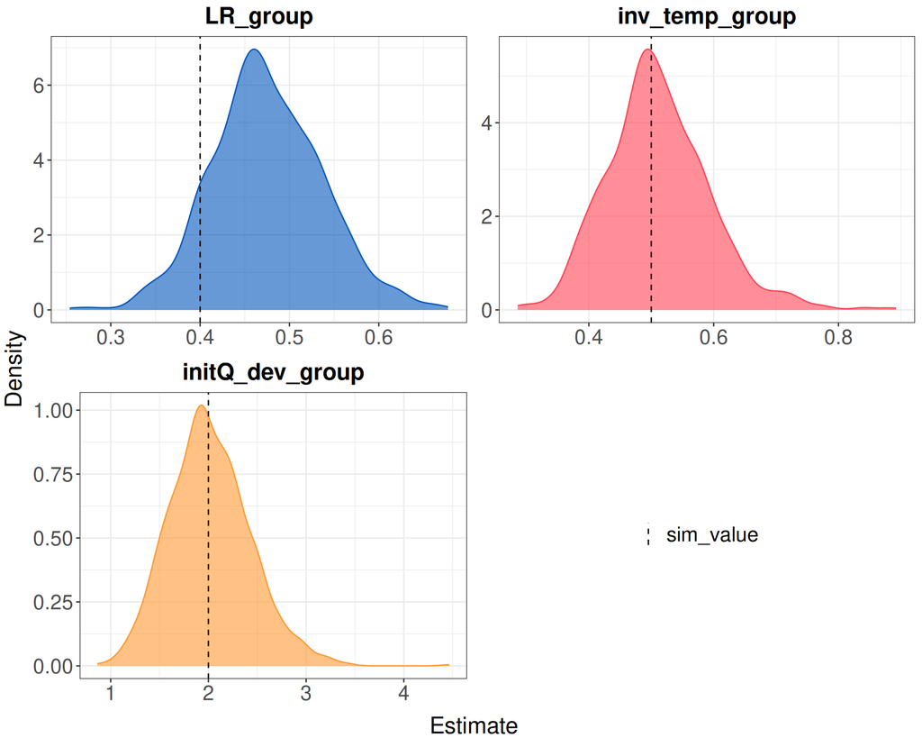

```r
free_params_group <- c("LR_group", "inv_temp_group", "initQ_dev_group")

draws <- readRDS(paste0(dat_dir, "draws.rds"))
draws <- draws %>%
  rename(setNames(paste0("means[", seq_along(free_params_group), "]"),
                  free_params_group))
to_plot <- free_params_group
plot$posterior_densities(draws, to_plot, params)
```

```r
util <- new.env()
source(paste0(util_dir, "utils.R"), local = util) # access functions using util$fun()
to_inspect <- free_params_group
util$print_posterior_table(draws, params, to_inspect)
```

Posteriors for free parameters

| Parameter | Simulated value | Median [95% credibility interval] |
| --- | --- | --- |
| LR_group | 0.4 | 0.47 [0.36, 0.60] |
| inv_temp_group | 0.5 | 0.51 [0.37, 0.70] |
| initQ_dev_group | 2.0 | 1.98 [1.27, 2.93] |

### 3.1.3 Participant-level parameters

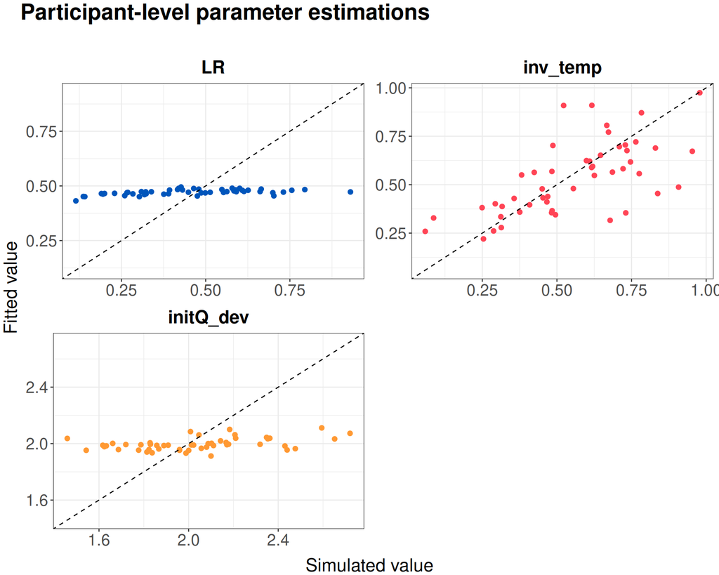

```r
participant_params <- rjson::fromJSON(file = paste0(dat_dir, "sim_param_settings_1.json"))
free_params_pp <- gsub("_group", "", free_params_group)
plot$pp_level_param_fit(draws, free_params_pp, participant_params)
```

TODO: for inv_temp it seems okay, but for the other parameters the participant-level estimations are very similar to the group-level estimations. Seems like a mistake?

## 3.2 Many runs: random parameters

To check parameter recovery across a range of parameter values, I run the model a bunch of times with different parameter settings. More specifically, each parameter value is chosen randomly from its whole theoretical range.

```r
n_runs <- 100
dat_dir <- paste0(main_dir, "3_param_recovery/1_std/100_runs/")

# sim$run_many(params, dat_dir, n_runs)
# running this bit below takes at least an hour
# fitting$fit_many(dat_dir, model_path, fit_data_type = "draws", dat_dir, n_runs)
```

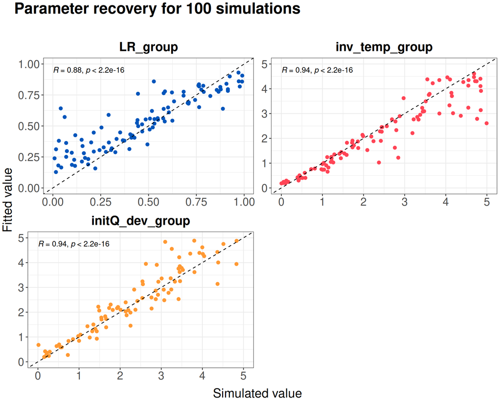

```r
sim_params <- data.frame(k = 1:n_runs)
fit_params <- data.frame(k = 1:n_runs)

for (k in 1:n_runs) {
  sim_file <- paste0(dat_dir, "param_settings_", sprintf("%03d", k), ".json")
  sim_dat <- rjson::fromJSON(file = sim_file)

  fit_file <- paste0(dat_dir, "draws_", sprintf("%03d", k), ".rds")
  fit_dat <- readRDS(fit_file) %>%
    rename(setNames(paste0("means[", seq_along(free_params_group), "]"),
                    free_params_group))

  for (p in free_params_group) {
    sim_params[[p]][k] <- sim_dat[[p]]
    fit_params[[p]][k] <- median(fit_dat[[p]])
  }
}

plot$many_runs_param_fit(sim_params, fit_params, free_params_group)
```